# 数学建模

### 模型知识点

### 高等数学-线性代数-线性无关

**Wang Haihua**

🚅 🚋😜 🚑 🚔

```python
import matplotlib.pyplot as plt
import numpy as np
from mpl_toolkits.mplot3d import Axes3D
import sympy as sy
sy.init_printing()
```

# Definition of Linear Independence

If all $c$'s are zero, the set of vectors $\{v_1, v_2,...,v_p\}$ is said to be linearly independent, if the equation

$$c_{1} {v}_{1}+c_{2} {v}_{2}+\cdots+c_{p} {v}_{p}=\mathbf{0}$$

holds.

However if any of $c$'s are nonzero, the set of vectors is linearly dependent.

## Example 1

Determine if ${v}_1, {v}_2, {v}_3$ are linearly independent. $${v}_{1}=\left[\begin{array}{l} 1 \\ 2 \\ 3 \end{array}\right]^T, {v}_{2}=\left[\begin{array}{l} 4 \\ 5 \\ 6 \end{array}\right]^T, \text { and } {v}_{3}=\left[\begin{array}{l} 2 \\ 1 \\ 0 \end{array}\right]^T$$

```python
A = sy.Matrix([[1,4,2,0],
               [2,5,1,0],
               [3,6,0,0]])
A.rref()
```

$\displaystyle \left( \left[\begin{matrix}1 & 0 & -2 & 0\\0 & 1 & 1 & 0\\0 & 0 & 0 & 0\end{matrix}\right], \ \left( 0, \ 1\right)\right)$

The solution shows that $x_3$ is a free variable, and naturally it could be nonzero, therefore the set is linearly dependent.

## Example 2

Consider a matrix $A$， determine columns of $A$ are linearly independent.

$$ A=\left[\begin{array}{rrr} 0 & 1 & 4 \\ 1 & 2 & -1 \\ 5 & 8 & 0 \end{array}\right] $$

Solve the system via augmented matrix.

```python
A = sy.Matrix([[0,1,4,0],[1,2,-1,0],[5,8,0,0]])
A.rref()
```

$\displaystyle \left( \left[\begin{matrix}1 & 0 & 0 & 0\\0 & 1 & 0 & 0\\0 & 0 & 1 & 0\end{matrix}\right], \ \left( 0, \ 1, \ 2\right)\right)$

$Ax=0$ has only trivial solution, so the columns of $A$ are linearly independent.

Linear independence is closly connected with linear combination, in next section we visualize the linear independence.

# Visualization of Linear Independence

Let's take a look an exmaple in $\mathbb{R}^2$, show $(3, 2)^T$, $(-9, -6)^T$, $(6, 4)^T$ are linearly dependent.

```python
fig, ax = plt.subplots(figsize = (8, 8))
#######################Arrows#######################
arrows = np.array([[[0,0,3,2]],
                   [[0,0,-9,-6]],
                   [[0,0,6,4]]])
colors = ['r','b','g']
for i in range(arrows.shape[0]):
    X,Y,U,V = zip(*arrows[i,:,:])
    ax.arrow(X[0], Y[0], U[0],V[0], color = colors[i], width = .18,
             length_includes_head = True,
             head_width = .3, # default: 3*width
             head_length = .6,
             overhang = .4, zorder = -i)

ax.scatter(0, 0, ec = 'red', fc = 'black', zorder = 5)
ax.text(6, 4, '$(6, 4)$')
ax.text(-9, -6.5, '$(-9, -6)$')
ax.text(3, 2, '$(3, 2)$')

ax.grid(True)
ax.set_title('Linear Dependence Visualization')
ax.axis([-10, 10, -10, 10])
ax.set_xlabel('x-axis', size = 18)
ax.set_ylabel('y-axis', size = 18)
```

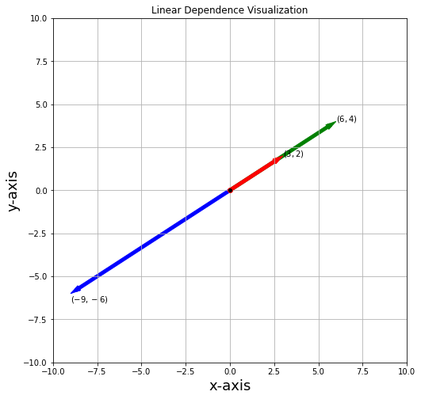

```python
plt.show()
```

Simply put, if one vector is the scalar multiple of the other, then these two vectors are linearly dependent.

Next, we visualize linear independence in $\mathbb{R}^3$. There are three vectors $(1,-2,1)^T$, $(2,1,2)^T$, $(-1,2,3)^T$, plot them in $\mathbb{R}^3$.

The standard procedure is to write down the span of first two vectors, which is a plane. Then we check if the third vector is in the plane or not. If not, this set of vectors is linearly independent.

$$ \left[ \begin{matrix} x\\ y\\ z \end{matrix} \right]= s\left[ \begin{matrix} 1\\ -2\\ 1 \end{matrix} \right]+ t\left[ \begin{matrix} 2\\ 1\\ 2 \end{matrix} \right]= \left[ \begin{matrix} s+2t\\ -2s+t\\ s+2t \end{matrix} \right] $$

```python
%matplotlib notebook

fig = plt.figure(figsize = (8,8))
ax = fig.add_subplot(projection='3d')

s = np.linspace(-1, 1, 10)
t = np.linspace(-1, 1, 10)
S, T = np.meshgrid(s, t)

X = S+2*T
Y = -2*S+T
Z = S+2*T
ax.plot_wireframe(X, Y, Z, linewidth = 1.5, color = 'k', alpha = .6)

vec = np.array([[[0, 0, 0, 1, -2, 1]],
               [[0, 0, 0, 2, 1, 2]],
               [[0, 0, 0, -1, 2, 3]]])
colors = ['r','b','g']
for i in range(vec.shape[0]):
    X, Y, Z, U, V, W = zip(*vec[i,:,:])
    ax.quiver(X, Y, Z, U, V, W, length=1, normalize=False, color = colors[i],
              arrow_length_ratio = .08, pivot = 'tail',
              linestyles = 'solid',linewidths = 3, alpha = .6)

ax.set_title('Linear Independence Visualization')

ax.set_xlabel('x-axis', size = 18)
ax.set_ylabel('y-axis', size = 18)
ax.set_zlabel('z-axis', size = 18)
```

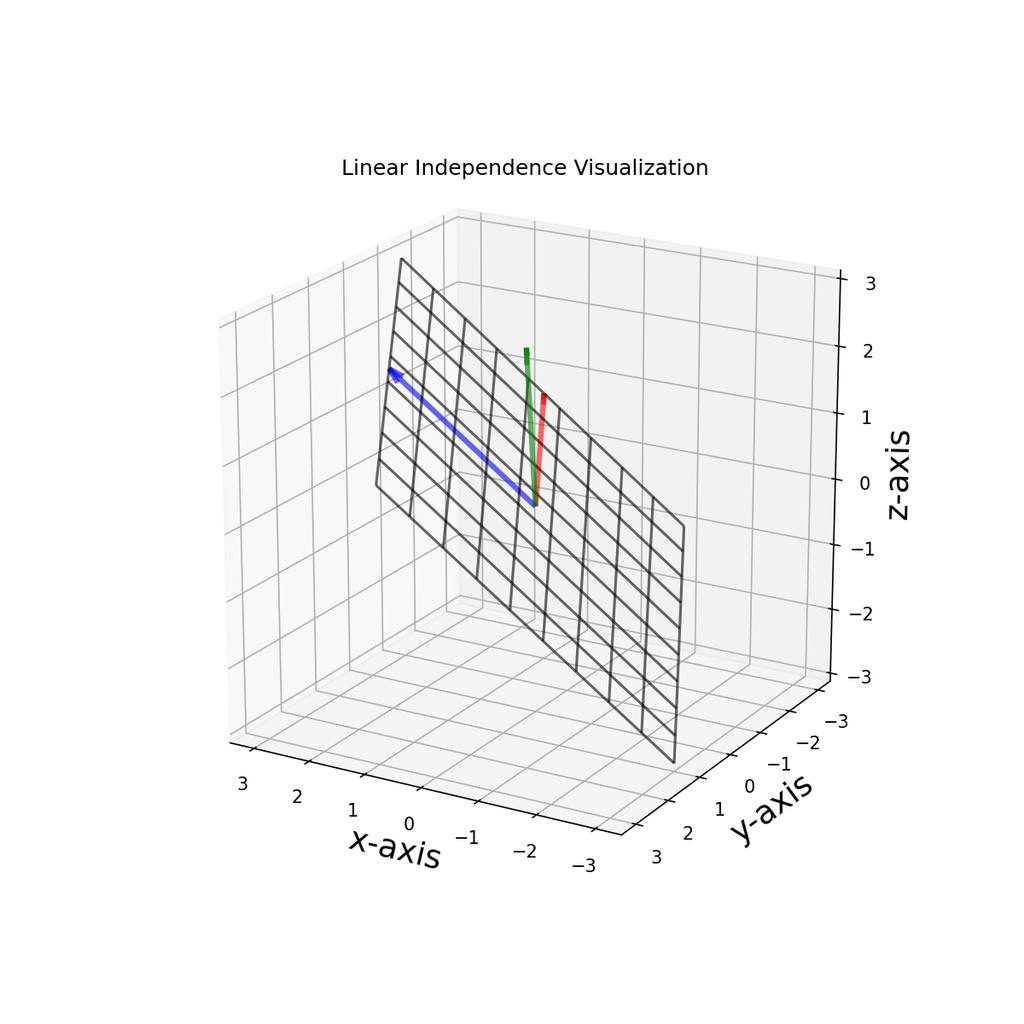

```python
ax.view_init(elev=20., azim=120)
```

Pan around the image, we can see that the green vector is not in the plane spanned by red and blue vector, thus they are linearly independent.

A Side Note for Linear Dependence

Let $S = \{{v}_1,{v}_2,{v}_3, ..., {v}_n\}$ be a set of vectors in $\mathbb{R}^m$, if $n>m$, then $S$ is linearly dependent.

It means the there must be at least one vector in the vector space spanned by the rest of vectors. For instance, a matrix $A$ which has 4 columns and 3 rows, then its columns are linear dependent.

Also if $S = \{{v}_1,{v}_2,{v}_3, ..., {v}_n\}$ contains a zero vector, then the set is linearly dependent as well.